# DYNECOM ECG synchrony

Ben Cowley

26 March 2019

# PARAMETERS

```r
# data-type parameters
basepath <- 'HRVcsv/'
feature <- 'rmssd' # OR stdevhr
# List of conditions
paircond <- c('a', 'b')
dyadcond <- c('D', 'S')
physcond <- c('both', 'eeg', 'resp', 'na')
timecond <- c('BL', '30s', '6min')
# Correlation method
cormeth <- 'pearson'
# # sliding window parameters
# wndw <- 60
# step <- wndw / 2 # 50% overlap steps
# method <- "mean" # options are: max, mean, median, min, prod, sd, sum, var; see ?RcppRoll
REPS <- 10000
```

# CODE WRANGLING

Here, as an example, we select condition *D, both, 6min* We collect *a* and *b* versions of the data (which are then bound together for convenience)

```r
# Create the first dataset as an example
cond_str <- paste0('_', dyadcond[1], '_', physcond[1], '.*', timecond[3])
dfa <- read_all_recordings(basepath, pat=paste0(paircond[1], cond_str), ext="csv")
dfb <- read_all_recordings(basepath, pat=paste0(paircond[2], cond_str), ext="csv")
dfa$ab <- 1
dfb$ab <- 2
df <- rbind(dfa, dfb)

subjs <- unique(df$Part)
sbjix <- seq(1, length(subjs))
```

# CORRELATION MATRICES

We don’t apply sliding window smoothing to HRV data because it already comes from a sliding window algorithm applied to the IBI signal, which is itself a dimensional reduction from the raw ECG signal.

Thus we calculate a correlation matrix for the given HRV signal, based on the Pearson correlation coefficient of *a* and *b* and the combination of all with all. The correlation matrix is displayed below.

The diagonal of the matrix (true dyad correlations) provides the test measurement. The diagonal is averaged (correlation aggregation is not needed because the number of elements per correlation is constant across dyads).

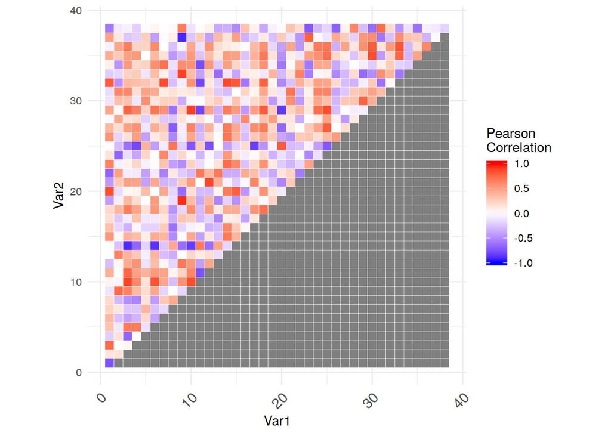

```r
Db6m.cormat <- corr_mat(df, feature, meth = cormeth)

Db6m.corr <- diag(Db6m.cormat$corr)
# Db6m.count <- Db6m.cormat$count

# Aggregates
Db6m.avg.cor <- mean(Db6m.corr)   # for constant N, Hunter-Schmidt aggregation is equivalent to average correlation
Db6m.abav.cor <- mean(abs(Db6m.corr)) # for constant N, Hunter-Schmidt aggregation is equivalent to average correlation

# show corr matrix
plot_rwb_cormat(Db6m.cormat$corr)
```

# MATRIX SAMPLING

To obtain a random sample (without replacement) of the pair-wise correlations, we simply shuffle the columns of the correlation matrix, displayed.

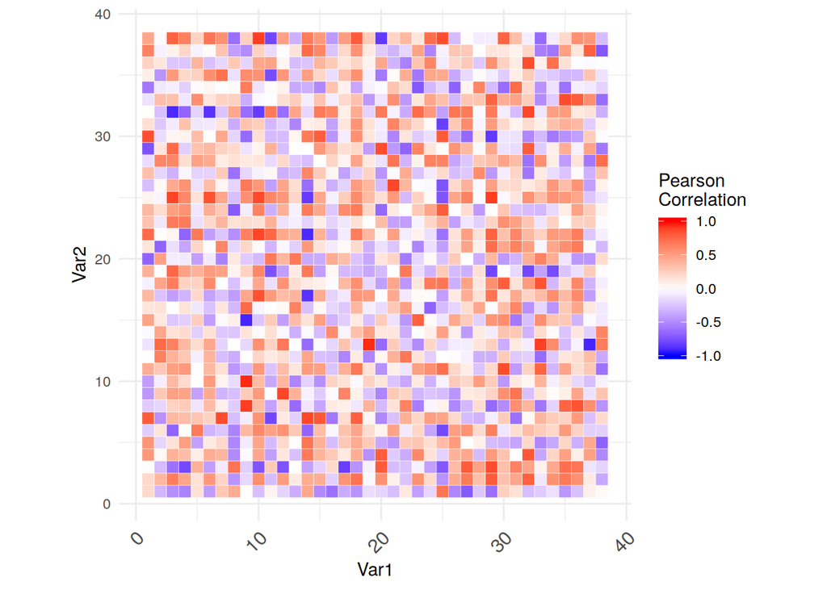

```r
samp <- sample_matrix(Db6m.cormat$corr, repl = FALSE)
plot_rwb_cormat(samp$sampmat)
```

# PERMUTATION TESTING

To obtain a permutation test statistic, we repeat the random sampling 10000 times, generating a distribution of correlations. We plot the observed real correlation against the distribution to see the statistical difference of the obervation from a random distribution. P values are obtained by counting how many permuted mean-differences are larger than the one we observed in our actual data. We can then divide this by the number of items in our permutation distribution.

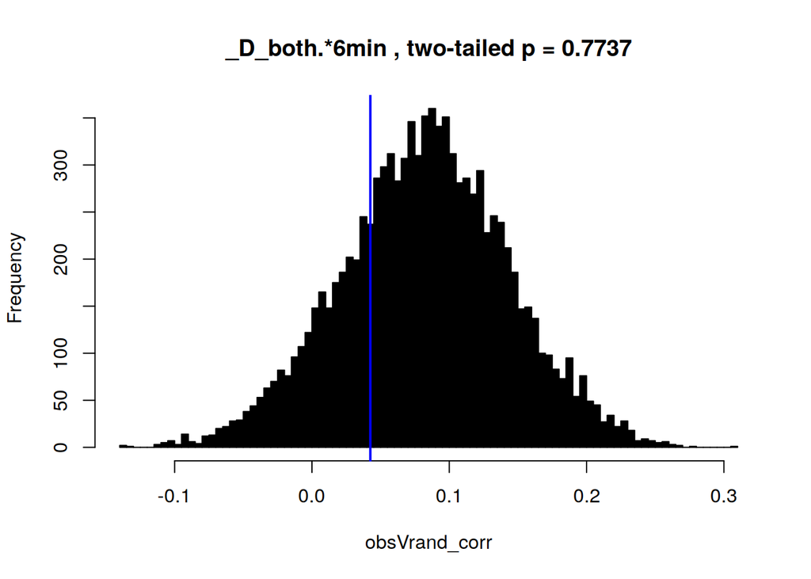

```r
# CONDITION D_both_6mins
obsVrand_corr <- replicate(REPS, sampmat_diag_stat(mean, Db6m.cormat$corr))
hist(obsVrand_corr, col='black', breaks=100,
     main = paste(cond_str, ", two-tailed p =", sum(abs(obsVrand_corr) > abs(Db6m.avg.cor)) / REPS))
abline(v=Db6m.avg.cor, col='blue', lwd=2)
```

## OTHER DYADIC CONDITIONS

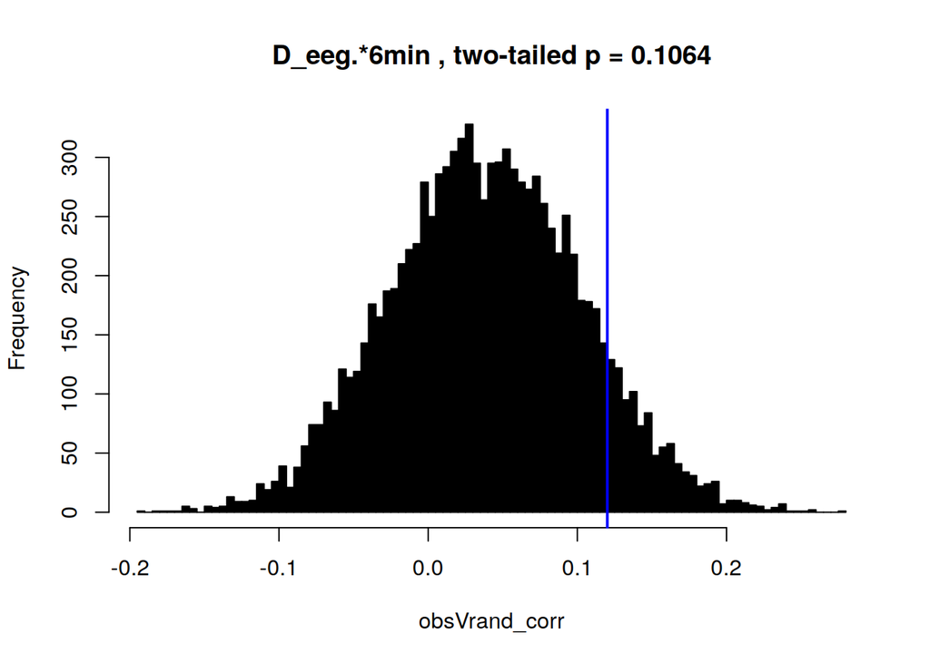

```r
# CONDITION D_eeg_6mins
cond_str <- paste0(dyadcond[1], '_', physcond[2], '.*', timecond[3])
patts <- c(paste0(paircond[1], '_', cond_str), paste0(paircond[2], '_', cond_str))
De6m.cor <- cond2cormat(basepath, patts, feature, cormeth, triangle = FALSE)
# Permutation testing
obsVrand_corr <- replicate(REPS, sampmat_diag_stat(mean, De6m.cor$cormat))
hist(obsVrand_corr, col='black', breaks=100,
     main = paste(cond_str, ", two-tailed p =", sum(abs(obsVrand_corr) > abs(De6m.cor$avg.cor)) / REPS))
abline(v=De6m.cor$avg.cor, col='blue', lwd=2)
```

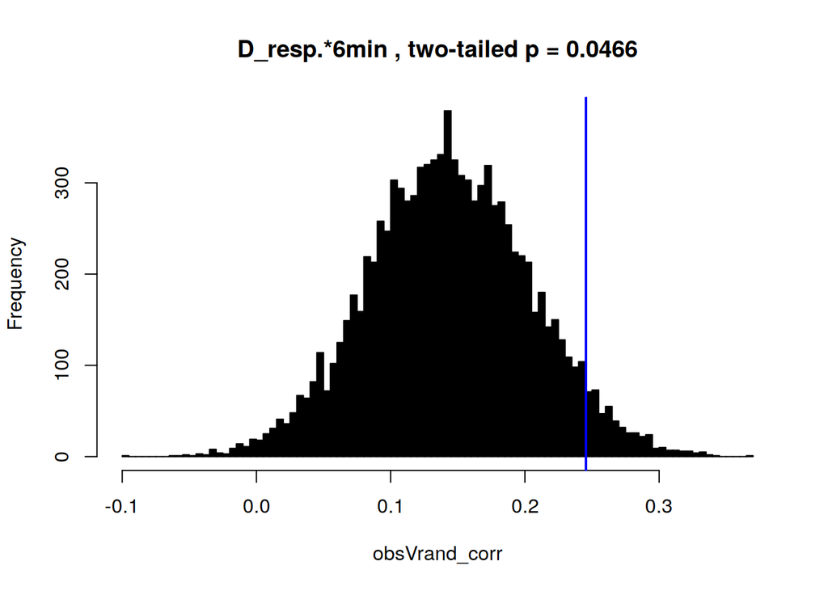

```r
# CONDITION D_resp_6mins
cond_str <- paste0(dyadcond[1], '_', physcond[3], '.*', timecond[3])
patts <- c(paste0(paircond[1], '_', cond_str), paste0(paircond[2], '_', cond_str))
Dr6m.cor <- cond2cormat(basepath, patts, feature, cormeth, triangle = FALSE)
# Permutation testing
obsVrand_corr <- replicate(REPS, sampmat_diag_stat(mean, Dr6m.cor$cormat))
hist(obsVrand_corr, col='black', breaks=100,
     main = paste(cond_str, ", two-tailed p =", sum(abs(obsVrand_corr) > abs(Dr6m.cor$avg.cor)) / REPS))
abline(v=Dr6m.cor$avg.cor, col='blue', lwd=2)
```

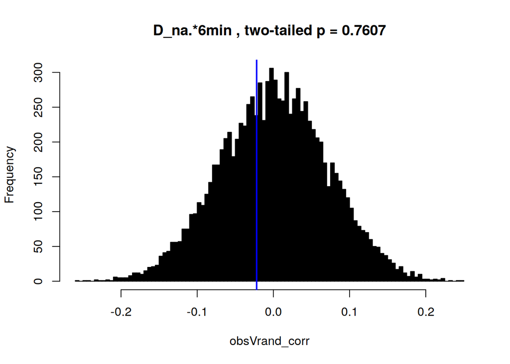

```r
# CONDITION D_na_6mins
cond_str <- paste0(dyadcond[1], '_', physcond[4], '.*', timecond[3])
patts <- c(paste0(paircond[1], '_', cond_str), paste0(paircond[2], '_', cond_str))
Dn6m.cor <- cond2cormat(basepath, patts, feature, cormeth, triangle = FALSE)
# Permutation testing
obsVrand_corr <- replicate(REPS, sampmat_diag_stat(mean, Dn6m.cor$cormat))
hist(obsVrand_corr, col='black', breaks=100,
     main = paste(cond_str, ", two-tailed p =", sum(abs(obsVrand_corr) > abs(Dn6m.cor$avg.cor)) / REPS))
abline(v=Dn6m.cor$avg.cor, col='blue', lwd=2)
```

## ALL SOLO CONDITIONS

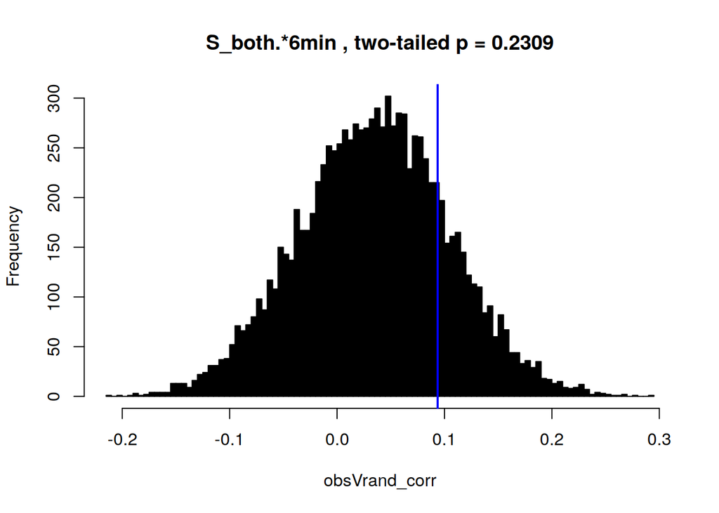

```r
# CONDITION S_both_6mins
cond_str <- paste0(dyadcond[2], '_', physcond[1], '.*', timecond[3])
patts <- c(paste0(paircond[1], '_', cond_str), paste0(paircond[2], '_', cond_str))
Sb6m.cor <- cond2cormat(basepath, patts, feature, cormeth, triangle = FALSE)
# Permutation testing
obsVrand_corr <- replicate(REPS, sampmat_diag_stat(mean, Sb6m.cor$cormat))
hist(obsVrand_corr, col='black', breaks=100,
     main = paste(cond_str, ", two-tailed p =", sum(abs(obsVrand_corr) > abs(Sb6m.cor$avg.cor)) / REPS))
abline(v=Sb6m.cor$avg.cor, col='blue', lwd=2)
```

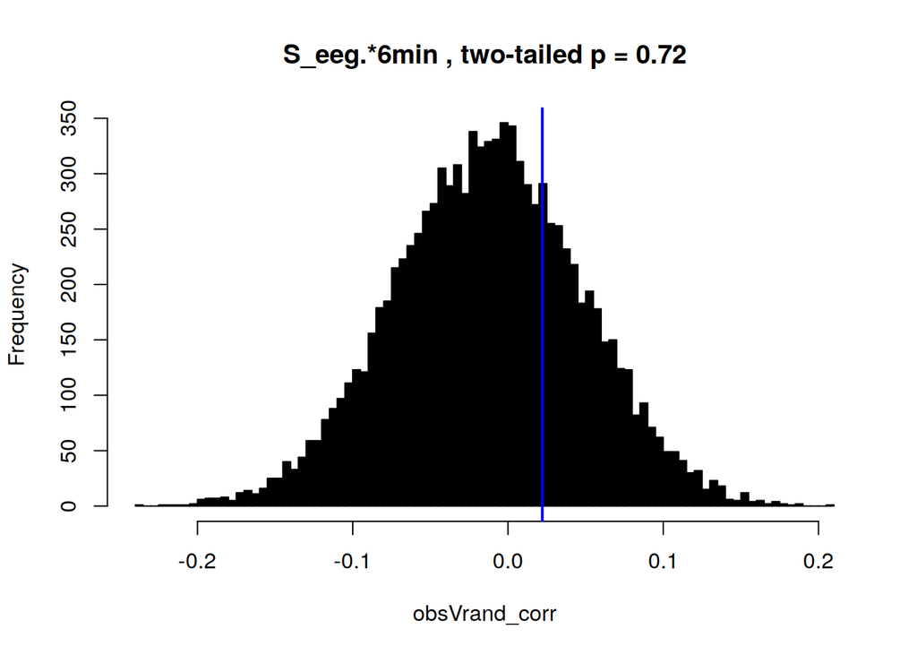

```r
# CONDITION S_eeg_6mins
cond_str <- paste0(dyadcond[2], '_', physcond[2], '.*', timecond[3])
patts <- c(paste0(paircond[1], '_', cond_str), paste0(paircond[2], '_', cond_str))
Se6m.cor <- cond2cormat(basepath, patts, feature, cormeth, triangle = FALSE)
# Permutation testing
obsVrand_corr <- replicate(REPS, sampmat_diag_stat(mean, Se6m.cor$cormat))
hist(obsVrand_corr, col='black', breaks=100,
     main = paste(cond_str, ", two-tailed p =", sum(abs(obsVrand_corr) > abs(Se6m.cor$avg.cor)) / REPS))
abline(v=Se6m.cor$avg.cor, col='blue', lwd=2)
```

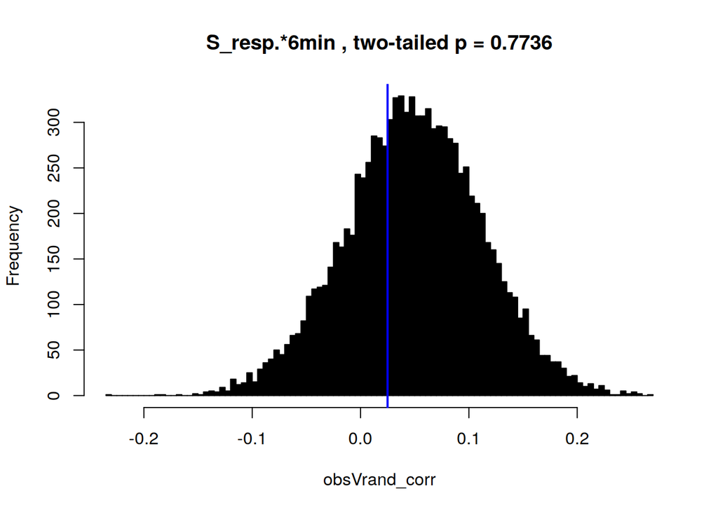

```r
# CONDITION S_resp_6mins
cond_str <- paste0(dyadcond[2], '_', physcond[3], '.*', timecond[3])
patts <- c(paste0(paircond[1], '_', cond_str), paste0(paircond[2], '_', cond_str))
Sr6m.cor <- cond2cormat(basepath, patts, feature, cormeth, triangle = FALSE)
# Permutation testing
obsVrand_corr <- replicate(REPS, sampmat_diag_stat(mean, Sr6m.cor$cormat))
hist(obsVrand_corr, col='black', breaks=100,
     main = paste(cond_str, ", two-tailed p =", sum(abs(obsVrand_corr) > abs(Sr6m.cor$avg.cor)) / REPS))
abline(v=Sr6m.cor$avg.cor, col='blue', lwd=2)
```

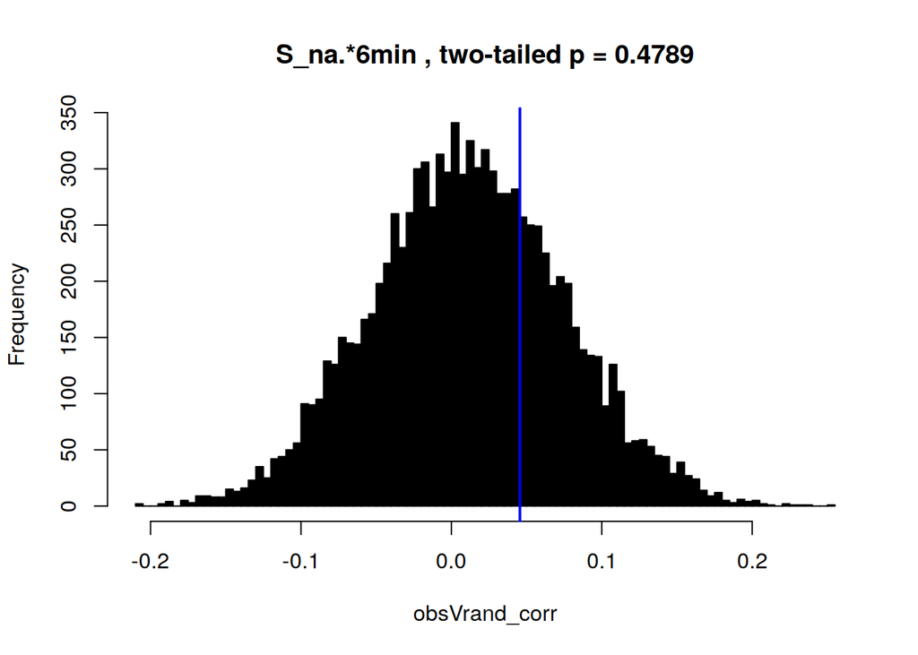

```r
# CONDITION S_na_6mins
cond_str <- paste0(dyadcond[2], '_', physcond[4], '.*', timecond[3])
patts <- c(paste0(paircond[1], '_', cond_str), paste0(paircond[2], '_', cond_str))
Sn6m.cor <- cond2cormat(basepath, patts, feature, cormeth, triangle = FALSE)
# Permutation testing
obsVrand_corr <- replicate(REPS, sampmat_diag_stat(mean, Sn6m.cor$cormat))
hist(obsVrand_corr, col='black', breaks=100,
     main = paste(cond_str, ", two-tailed p =", sum(abs(obsVrand_corr) > abs(Sn6m.cor$avg.cor)) / REPS))
abline(v=Sn6m.cor$avg.cor, col='blue', lwd=2)
```